# Predictors of Body Fat

by Sahir Bhatnagar

2019-05-14

# 1 Introduction

Identifying overweight populations is an important first step in fighting the obesity epidemic. However, accurate measure of body fat are costly and inconvenient. Therefore we are interested in determining predictors of body fat which require only a scale and a measuring tape. We analyze a dataset which contains percentage of body fat, age, weight, height and ten body circumference measurements for 251 men (Johnson 1996; Penrose, Nelson, and Fisher 1985). We model the data using multiple linear regression and perform various model selection techniques.

# 2 Exploratory Analysis

A pairs plot is presented in Figure 2.1

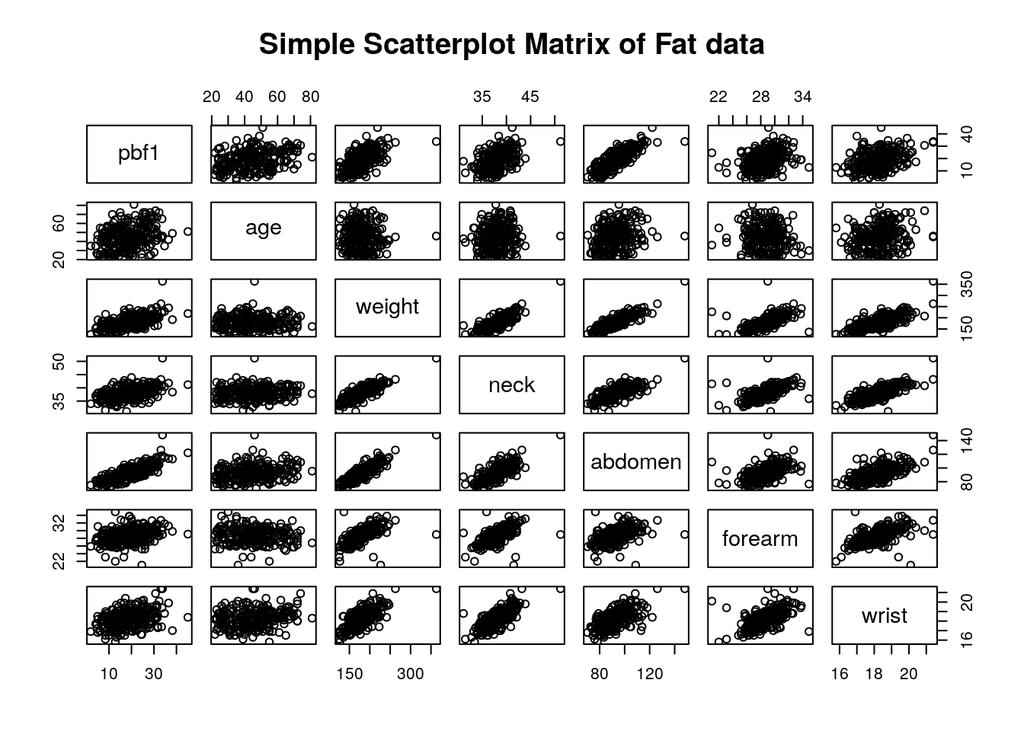

Figure 2.1: Pairs plot of Body Fat data

We will fit a linear regression model of the form

$$\begin{multline}
pbf1_i= \beta_0+\beta_1\textrm{age}_i+\beta_2\textrm{weight}_i+\beta_3\textrm{height}_i+\beta_4\textrm{neck}_i \\
+\beta_5\textrm{chest}+\beta_6\textrm{abdomen}_i+\beta_7\textrm{hip}_i+\beta_8\textrm{thigh}_i+\beta_9\textrm{knee}_i \\
+\beta_{10}\textrm{ankle}_i+ \beta_{11}\textrm{bicep}_i +\beta_{12}\textrm{forearm}_i +\beta_{13}\textrm{wrist}_i + \varepsilon
\end{multline}$$

# 3 Results

|  | Percentage Body Fat |  |  |
| --- | --- | --- | --- |
| Predictors | Estimates | CI | p |
| (Intercept) | -12.39 | -44.10 – 19.32 | 0.445 |
| age | 0.06 | -0.00 – 0.11 | 0.065 |
| weight | -0.07 | -0.17 – 0.02 | 0.136 |
| height | -0.07 | -0.25 – 0.10 | 0.417 |
| neck | -0.43 | -0.85 – -0.01 | **0.046** |
| chest | -0.04 | -0.22 – 0.14 | 0.668 |
| abdomen | 0.89 | 0.73 – 1.04 | **<0.001** |
| hip | -0.20 | -0.47 – 0.06 | 0.135 |
| thigh | 0.21 | -0.05 – 0.48 | 0.114 |
| knee | -0.02 | -0.45 – 0.42 | 0.946 |
| ankle | 0.15 | -0.25 – 0.55 | 0.458 |
| bicep | 0.17 | -0.14 – 0.48 | 0.295 |
| forearm | 0.42 | 0.05 – 0.78 | **0.025** |
| wrist | -1.49 | -2.46 – -0.52 | **0.003** |
| Observations | 251 |  |  |
| R<sup>2</sup> / adjusted R<sup>2</sup> | 0.745 / 0.731 |  |  |

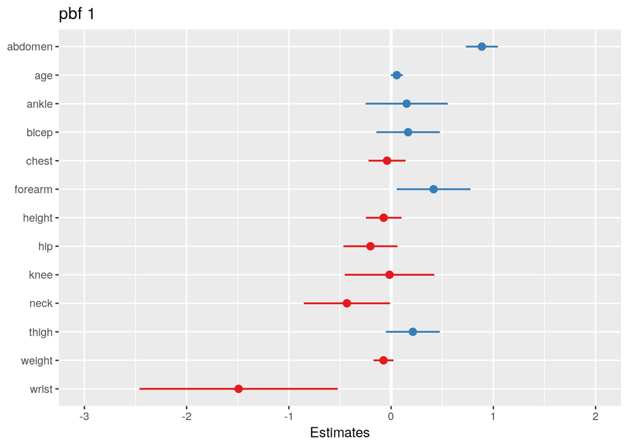

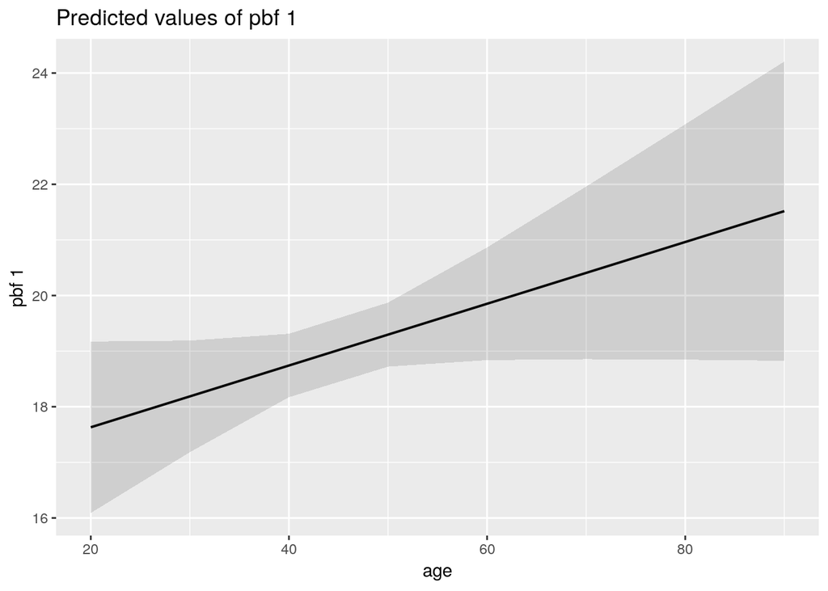

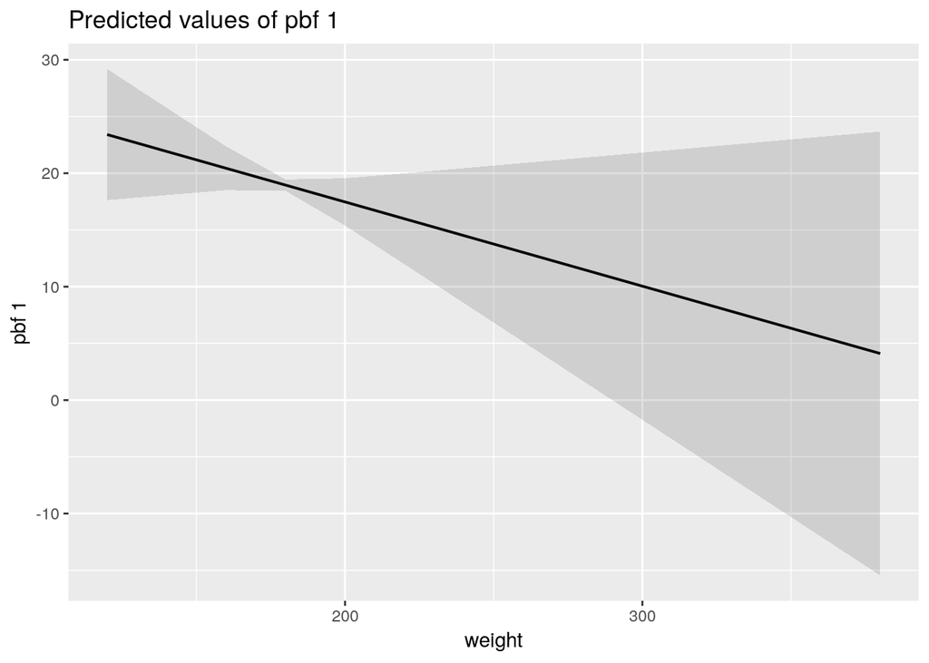

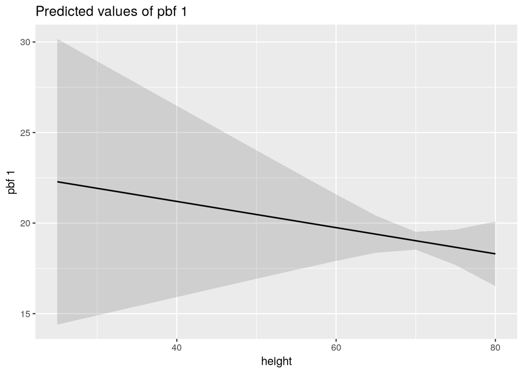

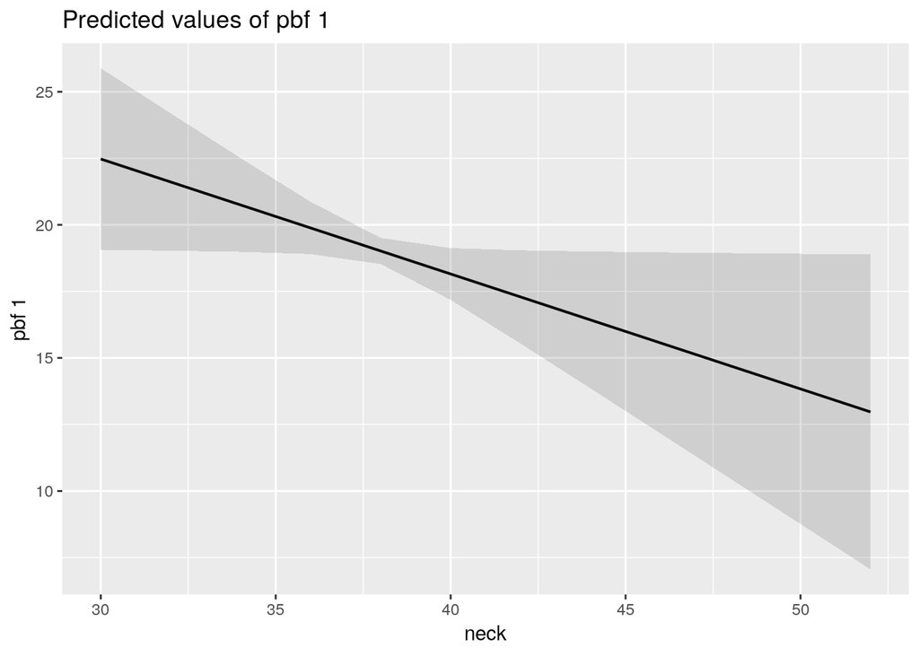

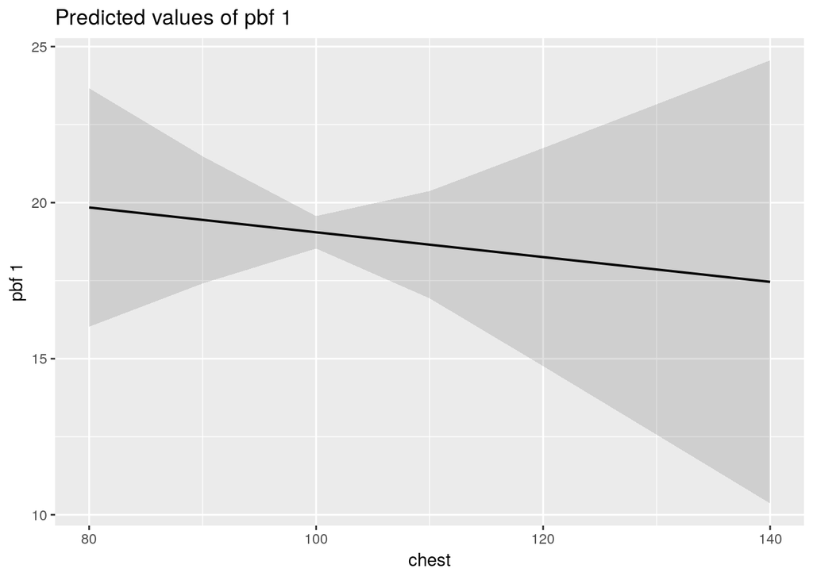

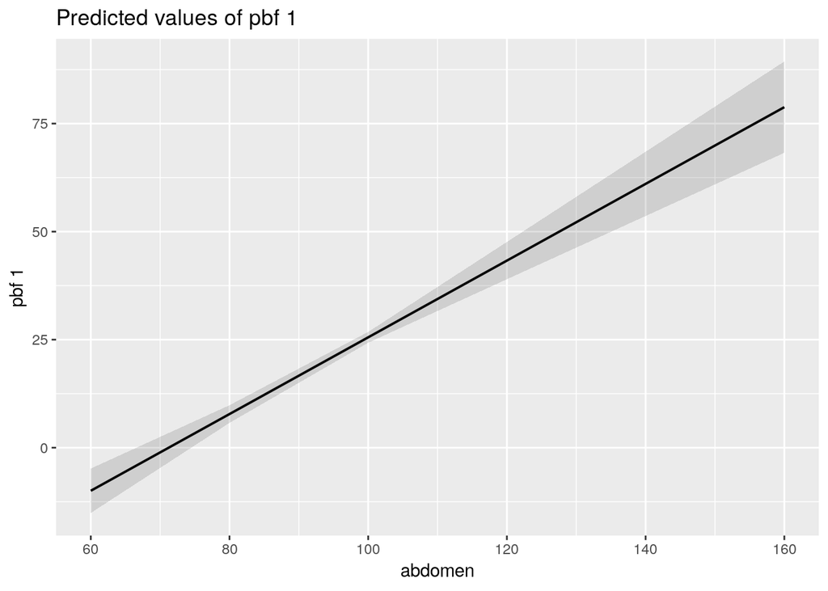

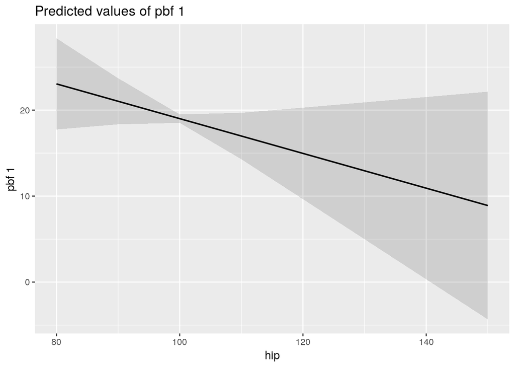

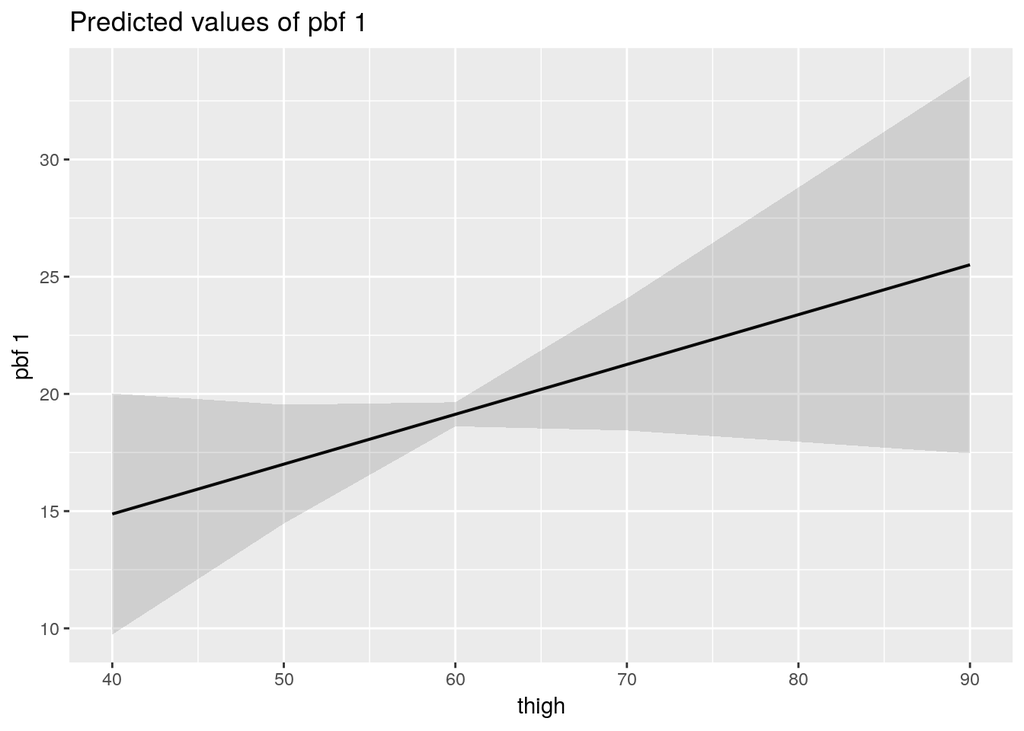

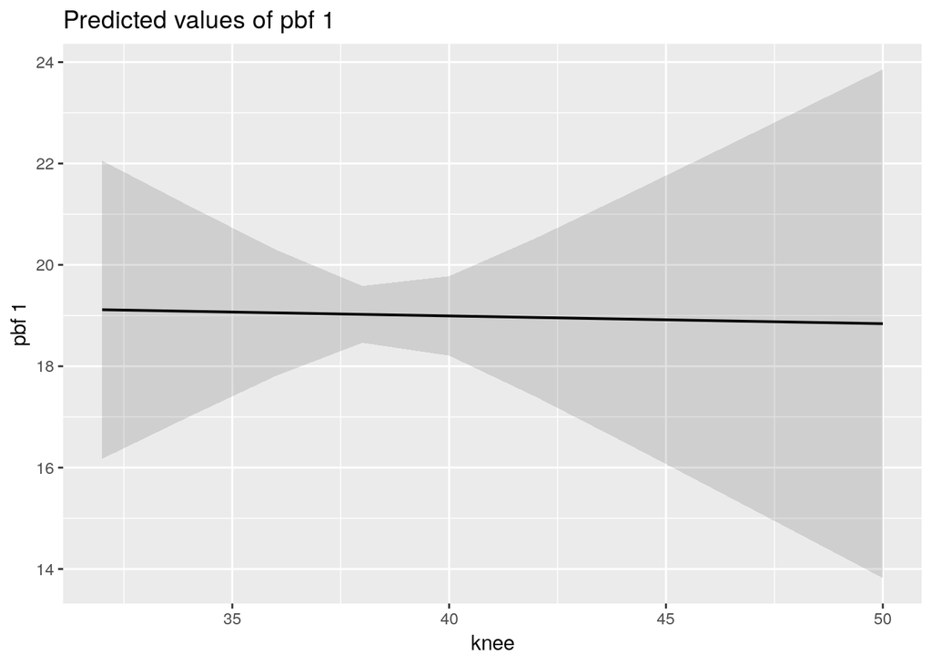

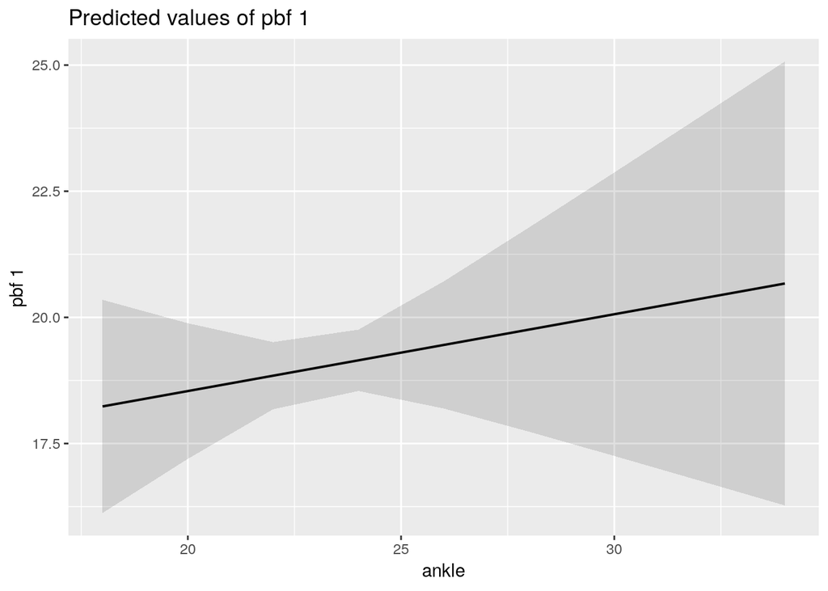

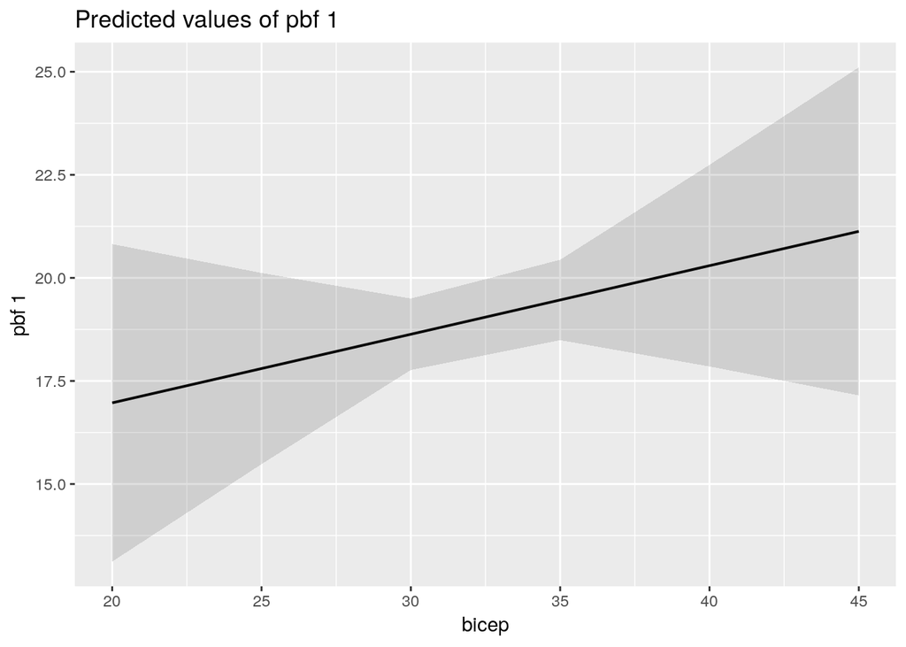

[2 more figures not shown]

Model diagnostics are shown in Figures 3.1 and 3.2

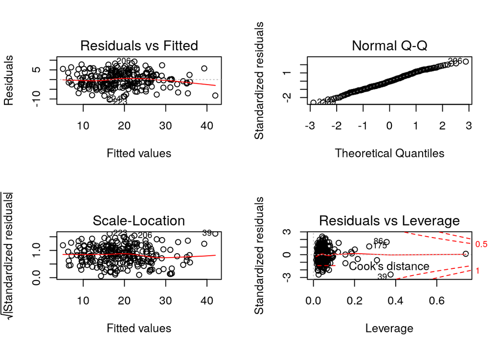

Figure 3.1: Diagnostic 1

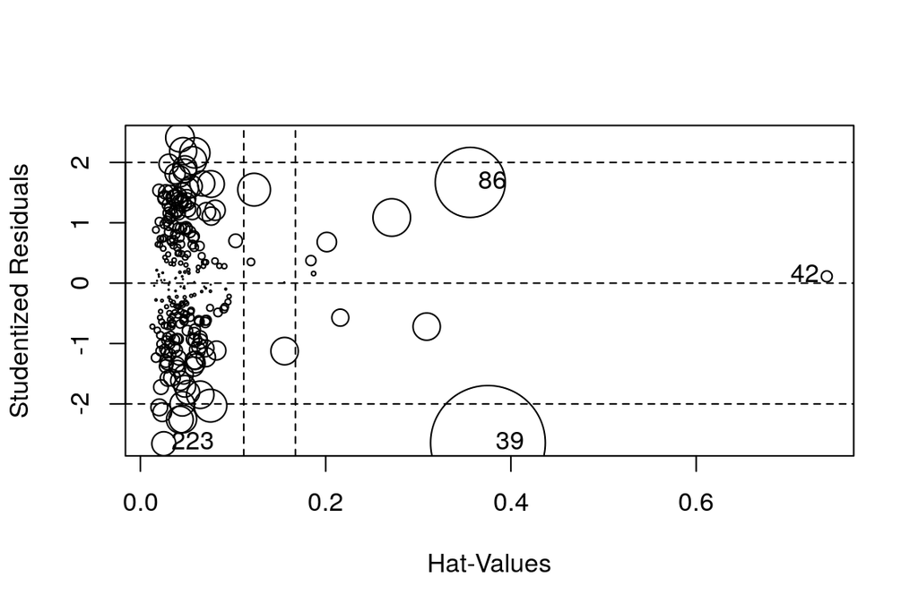

Figure 3.2: Regression influence plot

Look more closely at observation 42:

| pbf1 | weight | height |
| --- | --- | --- |
| 31.7 | 205 | 29.5 |

It’s unlikely someone weighs 205 pounds and only has a height of 29.5 inches.

# 4 Sensitivity Analysis

We perform the same analysis as above, but with observation 42 removed

We compare both fits in the following table:

|  | With obs. 42 |  |  | Without obs. 42 |  |  |
| --- | --- | --- | --- | --- | --- | --- |
| Predictors | Estimates | CI | p | Estimates | CI | p |
| (Intercept) | -12.39 | -44.10 – 19.32 | 0.445 | -13.85 | -54.56 – 26.86 | 0.505 |
| age | 0.06 | -0.00 – 0.11 | 0.065 | 0.06 | -0.00 – 0.11 | 0.065 |
| weight | -0.07 | -0.17 – 0.02 | 0.136 | -0.08 | -0.19 – 0.04 | 0.180 |
| height | -0.07 | -0.25 – 0.10 | 0.417 | -0.06 | -0.38 – 0.27 | 0.734 |
| neck | -0.43 | -0.85 – -0.01 | **0.046** | -0.43 | -0.86 – 0.00 | 0.052 |
| chest | -0.04 | -0.22 – 0.14 | 0.668 | -0.04 | -0.23 – 0.15 | 0.704 |
| abdomen | 0.89 | 0.73 – 1.04 | **<0.001** | 0.89 | 0.73 – 1.05 | **<0.001** |
| hip | -0.20 | -0.47 – 0.06 | 0.135 | -0.20 | -0.47 – 0.07 | 0.141 |
| thigh | 0.21 | -0.05 – 0.48 | 0.114 | 0.22 | -0.05 – 0.48 | 0.116 |
| knee | -0.02 | -0.45 – 0.42 | 0.946 | -0.02 | -0.47 – 0.43 | 0.928 |
| ankle | 0.15 | -0.25 – 0.55 | 0.458 | 0.15 | -0.25 – 0.56 | 0.455 |
| bicep | 0.17 | -0.14 – 0.48 | 0.295 | 0.17 | -0.15 – 0.48 | 0.293 |
| forearm | 0.42 | 0.05 – 0.78 | **0.025** | 0.42 | 0.05 – 0.78 | **0.026** |
| wrist | -1.49 | -2.46 – -0.52 | **0.003** | -1.49 | -2.46 – -0.52 | **0.003** |
| Observations | 251 |  |  | 250 |  |  |
| R<sup>2</sup> / adjusted R<sup>2</sup> | 0.745 / 0.731 |  |  | 0.742 / 0.728 |  |  |

# Code

```r
# can set global options here
knitr::opts_chunk$set(echo = FALSE, warning = FALSE, message = FALSE)

# you can create custom chunk options
knitr::opts_template$set(
  fig.large = list(fig.width = 7, fig.height = 5, fig.align = 'center', fig.pos = 'h'),
  fig.small = list(fig.width = 6, fig.height = 4, fig.align = 'center', fig.pos = 'h'),
  fig.full = list(fig.width = 8, fig.height = 6, fig.align = 'center', fig.pos = 'h')
)

# read in scripts. Note: this will not run the code.
# Like a 'promise'
if (!require("pacman")) install.packages("pacman")
pacman::p_load(here) # needed for filepaths

knitr::read_chunk(here::here("R", "001-packages.R"))
knitr::read_chunk(here::here("R", "001-data.R"))
knitr::read_chunk(here::here("R", "001-analysis.R"))
knitr::kable(DT[42,.(pbf1,weight,height),])
print(sessionInfo(), locale = FALSE)
#########################################################
# R Source code file for required packages
# for 001-motivating-example.Rmd/Rnw
# Hosted on github repo 'sahirbhatnagar/raqc'
# Author: Sahir Bhatnagar
# Created: May 31, 2018
# Updated:
# Notes: we use pacman to install packages. p_load will
# check if the package is installed, install and load it
#########################################################
if (!require("pacman")) install.packages("pacman")

pacman::p_load(knitr)

# for easy location of files
pacman::p_load(here)

# data loading and manipulation
pacman::p_load(data.table)

# easy plotting and tables of regression output
pacman::p_load(sjPlot)
pacman::p_load(ggeffects)

# influencePlot
pacman::p_load(car)

# the pipe %>%
pacman::p_load(magrittr)

# this allows you to use bookdown::html_document2 in the YAML
# which allows for figure labelling and referencing
pacman::p_load(bookdown)
#########################################################
# R Source code file for loading data
# for 001-motivating-example.Rmd.
# Hosted on github repo 'sahirbhatnagar/CSSC2018'
# Author: Sahir Bhatnagar
# Created: May 31, 2018
# Updated:
# Notes: This script contains everything related to data
# cleaning. In this example, there isn't any cleaning to do
# but the is NEVER the case in real life consulting.
#########################################################


# Description of variables
# 1. Percent body fat using Method 1: 457/Density - 414.2
# 2. Age (yrs)
# 3. Weight (lbs)
# 4. Height (inches)
# 5. Neck circumference (cm)
# 6. Chest circumference (cm)
# 7. Abdomen circumference (cm) “at the umbilicus and level with the iliac crest”
# 8. Hip circumference (cm)
# 9. Thigh circumference (cm)
# 10. Knee circumference (cm)
# 11 Ankle circumference (cm)
# 12. Extended biceps circumference (cm)
# 13. Forearm circumference (cm)
# 14. Wrist circumference (cm) “distal to the styloid processes”
#######################################################################
file_path <- here::here("data", "fat-data.csv")
DT <- data.table::fread(file_path)
#########################################################
# R Source code file for analysis
# for 001-motivating-example.Rmd.
# Hosted on github repo 'sahirbhatnagar/CSSC2018'
# Author: Sahir Bhatnagar
# Created: May 31, 2018
# Updated:
# Notes:
#########################################################
graphics::pairs(~ pbf1 + age + weight + neck + abdomen + forearm +
                  wrist, data = DT, main = "Simple Scatterplot Matrix of Fat data")
fit1 <- lm(pbf1 ~ ., data = DT)
texreg(fit1, digits=2, caption='Multiple Linear Regression of the Body Fat Data', label = "tab:results",
               booktabs = TRUE, dcolumn = TRUE, single.row = TRUE, use.packages = FALSE)
# print results to a table
sjPlot::tab_model(fit1, dv.labels = "Percentage Body Fat")
# plot coefficients
sjPlot::plot_model(fit1, type = "est")
par(mfrow=c(2,2))
plot(fit1)
sjPlot::plot_model(fit1, type = "pred")
car::influencePlot(fit1)
DT2 <- DT[-c(42), , ]
fit2 <- lm(pbf1~., data = DT2)
sjPlot::tab_model(fit1, fit2,
                  dv.labels = c("With obs. 42","Without obs. 42"),
                  p.style = "numeric")
texreg::texreg(list(fit1,fit2), digits=2,custom.model.names = c("With obs. 42","Without obs. 42"),
               caption='Sensitivity analsysis; Multiple Linear Regression of the Body Fat Data',
               label = "tab:results2", booktabs = TRUE, dcolumn = TRUE, single.row = TRUE, use.packages = FALSE)
par(mfrow=c(2,2))
plot(fit2)
car::influencePlot(fit2)
```

# References

Johnson, Roger W. 1996. “Fitting Percentage of Body Fat to Simple Body Measurements.” *Journal of Statistics Education* 4 (1): 265–66.

Penrose, Keith W, AG Nelson, and A Garth Fisher. 1985. “GENERALIZED Body Composition Prediction Equation for Men Using Simple Measurement Techniques.” *Medicine & Science in Sports & Exercise* 17 (2). LWW: 189.